# FullCode_Additional__Project_AML-1

## Model Comparison and Final Model Selection

```python
# training performance comparison

models_train_comp_df = pd.concat(
    [
        gbm1_train.T,
        gbm2_train.T,
        xgb1_train.T,
        xgb2_train.T,
        bag1_train.T,
        rf1_train.T,
    ],
    axis=1,
)
models_train_comp_df.columns = [
    "Gradient boosting trained with Original data",
    "Gradient boosting trained with Undersampled data",
    "XGBoost trained with Original data",
    "XGBoost trained with Undersampled data",
    "Bagging trained with Original data",
    "Random Forest trained with Oversampled data",
]
print("Training performance comparison:")
models_train_comp_df
```

```
Training performance comparison:
```

|  | Gradient boosting trained with Original data | Gradient boosting trained with Undersampled data | XGBoost trained with Original data | XGBoost trained with Undersampled data | Bagging trained with Original data | Random Forest trained with Oversampled data |
| --- | --- | --- | --- | --- | --- | --- |
| Accuracy | 0.941 | 0.769 | 0.943 | 0.764 | 0.998 | 0.995 |
| Recall | 0.329 | 0.718 | 0.375 | 0.665 | 0.975 | 0.992 |
| Precision | 0.954 | 0.800 | 0.903 | 0.830 | 1.000 | 0.999 |
| F1 | 0.489 | 0.756 | 0.530 | 0.738 | 0.988 | 0.995 |

```python
# Validation performance comparison

models_train_comp_df = pd.concat(
    [
        gbm1_val.T,
        gbm2_val.T,
        xgb1_val.T,
        xgb2_val.T,
        bag1_val.T,
        rf1_val.T,
    ],
    axis=1,
)
models_train_comp_df.columns = [
    "Gradient boosting trained with Original data",
    "Gradient boosting trained with Undersampled data",
    "XGBoost trained with Original data",
    "XGBoost trained with Undersampled data",
    "Bagging trained with Original data",
    "Random Forest trained with Oversampled data",
]
print("Validation performance comparison:")
models_train_comp_df
```

```
Validation performance comparison:
```

|  | Gradient boosting trained with Original data | Gradient boosting trained with Undersampled data | XGBoost trained with Original data | XGBoost trained with Undersampled data | Bagging trained with Original data | Random Forest trained with Oversampled data |
| --- | --- | --- | --- | --- | --- | --- |
| Accuracy | 0.939 | 0.775 | 0.939 | 0.810 | 0.937 | 0.911 |
| Recall | 0.316 | 0.673 | 0.346 | 0.623 | 0.320 | 0.288 |
| Precision | 0.922 | 0.225 | 0.846 | 0.252 | 0.854 | 0.461 |
| F1 | 0.470 | 0.338 | 0.491 | 0.359 | 0.466 | 0.355 |

- XGBoost trained with Original data has generalised performance, so let's consider it as the best model.
- We should note that, 'Bagging Classifier trained on Original data' could also be considered as a next best model, as the models performance on validation data is 0.466 and the performance on Training data is 0.988, but this could also be because of overfitting. Hence we preferred XGBoost model trained on Original data.

### Test set final performance

```python
# Let's check the performance on test set
xgb1_test = model_performance_classification_sklearn(tuned_xgb1, X_test, y_test)
xgb1_test
```

|  | Accuracy | Recall | Precision | F1 |
| --- | --- | --- | --- | --- |
| 0 | 0.939 | 0.355 | 0.836 | 0.499 |

- The XGBoost model trained on original data has given ~49% F1 score on the test set
- This performance is in line with what we achieved with this model on the train and validation sets
- So, this is a generalized model

### Feature Importance

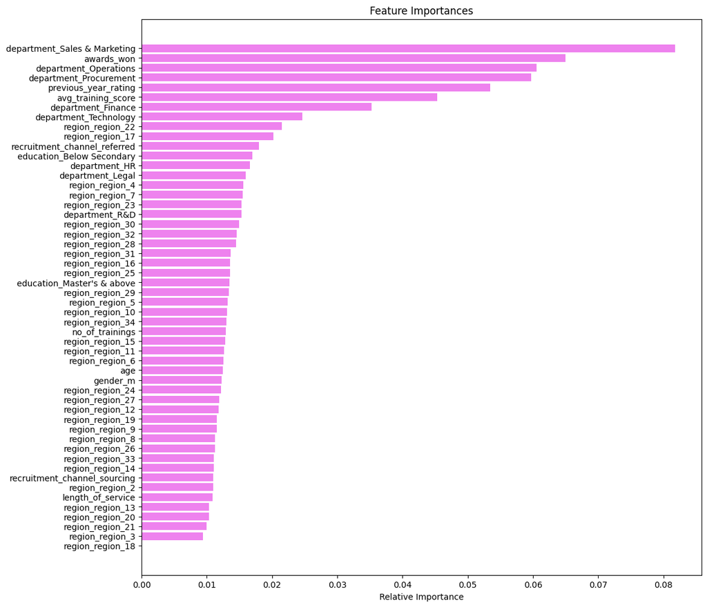

```python
feature_names = X_train.columns
importances = tuned_xgb1.feature_importances_
indices = np.argsort(importances)

plt.figure(figsize=(12, 12))
plt.title("Feature Importances")
plt.barh(range(len(indices)), importances[indices], color="violet", align="center")
plt.yticks(range(len(indices)), [feature_names[i] for i in indices])
plt.xlabel("Relative Importance")
plt.show()
```

- We can see that being part of 'Sales & Marketing' `department` or 'Operations' `department` has major importance in determining Promotion status.
- Besides this, variables such as `awards_won` and `previous_year_rating` has strong importance as well in determining the promotion status.

# Business Insights and Conclusions

- **With the predictive model that we built:**
  - The HR team of the company can predict if a person is eligible for promotion or not.
  - It can also help the HR team to identify which key factors influence the promotion status significantly.
- **Prioritize Employees in Key Departments:**
  - Focus on employees from the Sales & Marketing and Operations departments, as these groups have shown significant importance in determining promotion status. Special attention should be given to these departments during promotion cycles.
  - Also, given that these are the largest departments, closely evaluate the specific needs and performance criteria within these departments. Avoid over-promoting in these areas simply due to their size. Instead, focus on whether the individual’s skills align with the department’s future needs.
- **Leverage Awards Won as a Key Indicator:**
  - Employees who have won awards should be given higher consideration for promotions, as awards have the strongest positive correlation with promotion status. Encouraging a culture of recognition and reward could also motivate employees to perform better.
  - Ensure that the awards are merit-based and relevant to the role they will be promoted to.
- **Incorporate Previous Year’s Rating into the Decision-Making Process:**
  - Ensure that the previous year’s rating is a key criterion in promotion decisions. Employees with higher ratings in the previous year should be prioritized, as this metric is strongly associated with promotion likelihood.
  - Ensure that the rating system is accurate and reflective of actual performance.
- **Consider Average Training Scores:**
  - Use average training scores as another crucial factor in the promotion process. Employees who perform well in training are more likely to be strong candidates for promotion. Consider offering additional training and development opportunities to help more employees achieve high scores.
  - Consider making certain training programs mandatory for employees being considered for promotion to ensure they have the necessary skills.
- **Address Educational Backgrounds:**
  - While most employees have a Bachelor’s degree, consider providing additional support or development opportunities for those with below-secondary level education. This could help improve their chances of promotion and overall performance.
  - Use education as a baseline requirement but ensure that other factors like awards, training scores, and performance ratings are more heavily weighted in determining promotion eligibility.
- **Length of Service and Age:**
  - Avoid using tenure or age as a primary criterion for promotion. The data shows that these factors do not significantly impact promotion eligibility. Focus instead on actual performance and potential.
- **Gender Balance:**
  - Be aware that 70% of the employees are male. Ensure that promotion predictions are not biased by gender and that deserving employees, regardless of gender, are equally considered.
- **Region-Specific Analysis:**
  - Since region_2 is the largest, consider the regional performance trends when predicting promotions. Adjust promotion criteria slightly based on regional data to account for different operational challenges and opportunities in various regions.
- **Holistic Assessment:**
  - Combine performance metrics like awards won, previous year rating, and average training score with qualitative assessments, such as feedback from managers and peers, to make a well-rounded decision.
  - Avoid Biases: Ensure that promotion decisions are not influenced by biases related to gender, region, or education level. For example, despite the majority of employees having a bachelor's degree, consider the individual’s achievements and potential rather than just educational qualifications.
- **Recruitment Source:**
  - Be mindful of the recruitment source when considering promotions. For example, employees recruited via referrals or sourcing may need different developmental support compared to those recruited via other methods.
- **Continuous Monitoring:**
  - Regularly review and update the criteria for promotions to ensure they align with company goals and the evolving business environment.

By focusing on these recommendations, HR can make more informed and fair decisions, reducing the risk of promoting ineligible employees and ensuring that the most deserving candidates are recognized.